# Pauta Tarea 1

Facultad de Economía y Negocios, Universidad de Chile, Chile

2018-10-23 (updated: 2018-10-23)

**Instrucciones**

1. Esta tarea debe ser entregada en grupos de mínimo 2 alumnos y máximo 3 alumnos.
2. Se debe enviar una carpeta comprimida (.zip) la que debe contener: script y un breve informe con sus resultados, incluyendo tablas, gráficos, etc., según corresponda. El formato del infome puede ser word o pdf.
3. El asunto del email con su tarea debe ser “Tarea 1-Finanzas 1-Apellido 1-Apellido 2-Apellido 3”
4. La fecha de entrega es el Martes 28 de Agosto del 2018 hasta las 23:59 hrs al correo del curso: finance.hansen@gmail.com.

Usted es un analista de inversiones al cual se le ha encomendado la misión de construir un portafolio que buscará diversificación invirtiendo en distintas empresas. El monto a invertir es de US$1 millón.

# Selección de los datos

Desde [*Yahoo Finance*](https://finance.yahoo.com/) obtenga los precios de las siguientes empresas con periodicidad mensual desde Enero del 2005 hasta Julio del 2018: Amazon (AMZN), Alphabet (GOOG), Netflix (NFLX), McDonald`s (MCD) y Coca Cola (KO)

```r
# Cargamos librerias
if(!require("pacman")) install.packages("pacman")
p_load("readxl","quantmod","tidyverse","reshape2","fBasics","PerformanceAnalytics","quadprog",
       "IntroCompFinR")
```

```r
# Nuevos tickers
tickers <- c("AMZN","GOOG","NFLX","MCD","KO")
```

```r
# descargamos los tickers
getSymbols(tickers, src = "yahoo", from = "2004-12-01", to = "2018-08-01", periodicity = "monthly")
```

```
## [1] "AMZN" "GOOG" "NFLX" "MCD"  "KO"
```

```r
# Precio de cierre
list <-  lapply(tickers, function(x) Cl(get(x)))
precio.cierre <- do.call(merge,list)
```

```r
# removemos los objetos que no vamos a usar
rm("AMZN","GOOG","NFLX","MCD","KO", list)
```

# Retorno y estadística descriptiva

Para cada acción calcule el retorno y retorno acumulado, luego:

## Pregunta a

```r
# calculamos los  retornos
retornos <- data.frame(apply(precio.cierre, 2, function(x) Delt(x, type = "log")),
                      fecha = index(precio.cierre)) %>%
            na.omit()

# calculamos los retornos acumulados
acumulados <- data.frame(apply(retornos[1:5], 2, function(x) cumsum(x)),
                              fecha = index(precio.cierre[-1]))

# Cambiamos la forma de los datos
reshape.acumulados <- melt(acumulados, id.vars = "fecha")
```

Construimos el gráfico:

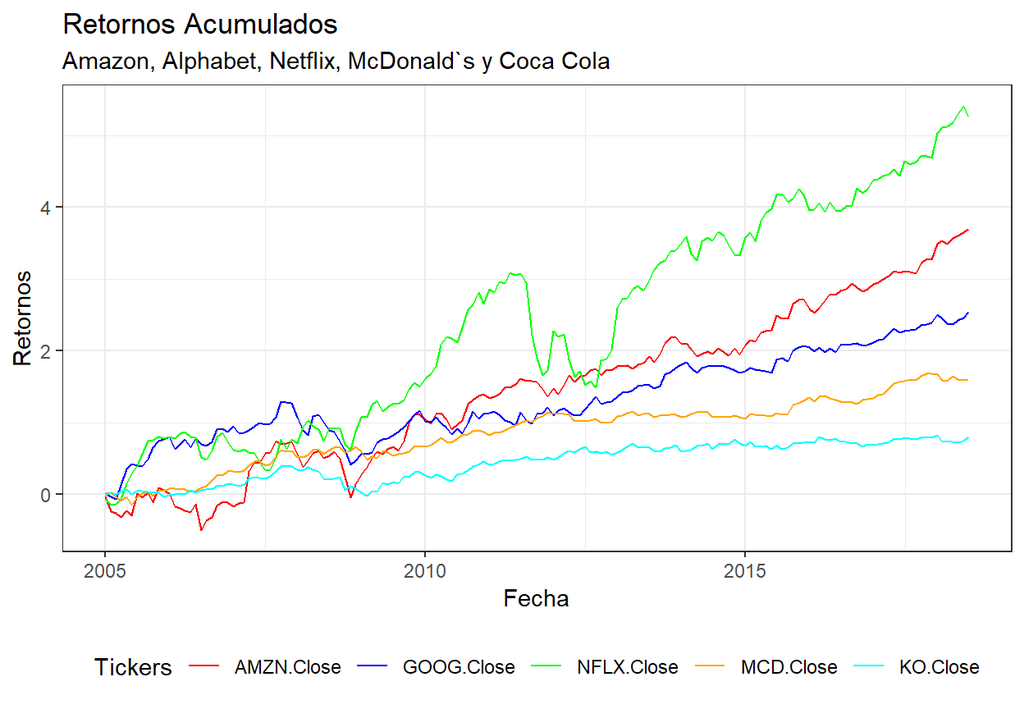

```r
# graficamos los retornos acumulados
g2 <- ggplot(reshape.acumulados) + geom_line(mapping = aes(fecha, value, color = variable))
g2 <- g2 + ggtitle("Retornos Acumulados",
                   subtitle="Amazon, Alphabet, Netflix, McDonald`s y Coca Cola")
g2 <- g2 + theme_bw() + xlab("Fecha") + ylab("Retornos")
g2 <- g2 + scale_color_manual("Tickers",
                              values = c("red","blue","green","orange", "cyan"))
g2 <- g2 + theme(legend.position = "bottom")
g2
```

## Pregunta b

```r
# calculo retorno esperado y desviación estandar
mean <- apply(retornos[,1:5], 2, function(x) mean(x))
sd <- apply(retornos[,1:5], 2, function(x) sd(x))
cov  <- cov(retornos[1:5])
```

[figure not shown]

```r
# graficamos el trade-off riesgo-retorno
g3 <- ggplot(mapping = aes(sd, mean, label = c("AMZN","GOOG","AAPL","MCD","KO")))
g3 <- g3 + geom_point() + geom_text(hjust = 0, vjust = 0)
g3 <- g3 + scale_y_continuous(breaks = seq(0,0.2, by = 0.01),limits = c(0,0.08))
g3 <- g3 + scale_x_continuous(breaks = seq(0,0.2, by = 0.02),limits = c(0,0.2))
g3 <- g3 + theme_bw() + xlab("Riesgo") + ylab("Retorno") +  ggtitle("Trade-off Riesgo-Retorno",
                                                                  subtitle = "Cinco activos riesgosos")
g3
```

## Pregunta c

Compute una estadística descriptiva (media, varianza, desviación estandar, skewness y kurtosis) para el retorno de cada acción y comente.

```r
# Estadística descriptiva
summary <- basicStats(retornos[1:5])[c("Mean", "Stdev", "Median", "Minimum", "Maximum",
                                       "Skewness","Kurtosis"),]
```

Estadística Descriptiva

|  | AMZN.Close | GOOG.Close | NFLX.Close | MCD.Close | KO.Close |
| --- | --- | --- | --- | --- | --- |
| Mean | 0.023 | 0.016 | 0.032 | 0.010 | 0.005 |
| Stdev | 0.104 | 0.082 | 0.154 | 0.043 | 0.042 |
| Median | 0.024 | 0.018 | 0.038 | 0.009 | 0.005 |
| Minimum | -0.364 | -0.204 | -0.730 | -0.109 | -0.182 |
| Maximum | 0.433 | 0.265 | 0.579 | 0.130 | 0.133 |
| Skewness | -0.070 | 0.065 | -0.368 | -0.121 | -0.513 |
| Kurtosis | 2.203 | 0.546 | 4.039 | 0.217 | 1.938 |

## Pregunta d

Usando una tasa libre de riesgo mensual igual a 0.1250% (0.00125), calcule el ratio de Sharpe para cada activo. ¿Qué activo posee el mayor ratio de Sharpe?

```r
# calculo ratio de sharpe
sr <- function(rf,ra,sd){

      sharpe.ratio <- (ra - rf)/sd
      sprintf("el ratio de sharpe es %4f",sharpe.ratio)

}

# contruyo un auxiliar
auxiliar <- data.frame(rbind(mean,sd))

# Tasa libre de riesgo
rf <- 0.00125
```

```r
# Calculo ratio de sharpe
for(i in 1:ncol(auxiliar)){

    print(paste0(sr(rf,auxiliar[1,i],auxiliar[2,i])," de ",colnames(auxiliar[i])))

}
```

```
## [1] "el ratio de sharpe es 0.206431 de AMZN.Close"
## [1] "el ratio de sharpe es 0.174500 de GOOG.Close"
## [1] "el ratio de sharpe es 0.201202 de NFLX.Close"
## [1] "el ratio de sharpe es 0.198409 de MCD.Close"
## [1] "el ratio de sharpe es 0.088268 de KO.Close"
```

## Pregunta e

```r
# Test de Jarque Bera
apply(retornos[1:5], 2, function(x) jarqueberaTest(x))
```

[output not shown]

# Teoría de portafolio

## Pregunta a

Construya el portafolio de minima varianza global. Reporte los ponderadores de este portfolio, su retorno esperado y su desviación estandar.

```r
# portafolio de mínima varianza
globalmin <- globalMin.portfolio(mean, cov, shorts = TRUE)
globalmin
```

```
## Call:
## globalMin.portfolio(er = mean, cov.mat = cov, shorts = TRUE)
##
## Portfolio expected return:     0.008270928
## Portfolio standard deviation:  0.03636602
## Portfolio weights:
## AMZN.Close GOOG.Close NFLX.Close  MCD.Close   KO.Close
##    -0.0347     0.0809     0.0378     0.4243     0.4917
```

## Pregunta b

Un portafolio cuyo retorno esperado sea igual al de Amazon (permitida venta corta). (*3 puntos*)

```r
efficient.portfolio(mean, cov, mean[1], shorts = TRUE)
```

```
## Call:
## efficient.portfolio(er = mean, cov.mat = cov, target.return = mean[1],
##     shorts = TRUE)
##
## Portfolio expected return:     0.02265135
## Portfolio standard deviation:  0.07228874
## Portfolio weights:
## AMZN.Close GOOG.Close NFLX.Close  MCD.Close   KO.Close
##     0.2528     0.2231     0.2445     0.8668    -0.5873
```

2. Un portafolio cuyo retorno esperado sea igual al de Alphabet (permitida venta corta). (*3 puntos*)

```r
efficient.portfolio(mean, cov, mean[2], shorts = TRUE)
```

```
## Call:
## efficient.portfolio(er = mean, cov.mat = cov, target.return = mean[2],
##     shorts = TRUE)
##
## Portfolio expected return:     0.01559746
## Portfolio standard deviation:  0.04832839
## Portfolio weights:
## AMZN.Close GOOG.Close NFLX.Close  MCD.Close   KO.Close
##     0.1118     0.1534     0.1431     0.6498    -0.0580
```

3. Un portafolio cuyo retorno esperado sea igual al de Netflix (permitida venta corta). (*3 puntos*)

```r
efficient.portfolio(mean, cov, mean[3], shorts = TRUE)
```

```
## Call:
## efficient.portfolio(er = mean, cov.mat = cov, target.return = mean[3],
##     shorts = TRUE)
##
## Portfolio expected return:     0.03224106
## Portfolio standard deviation:  0.1103047
## Portfolio weights:
## AMZN.Close GOOG.Close NFLX.Close  MCD.Close   KO.Close
##     0.4446     0.3180     0.3823     1.1619    -1.3068
```

4. Un portafolio cuyo retorno esperado sea igual al de McDonald`s (permitida venta corta). (*3 puntos*)

```r
efficient.portfolio(mean, cov, mean[4], shorts = TRUE)
```

```
## Call:
## efficient.portfolio(er = mean, cov.mat = cov, target.return = mean[4],
##     shorts = TRUE)
##
## Portfolio expected return:     0.009767302
## Portfolio standard deviation:  0.03694252
## Portfolio weights:
## AMZN.Close GOOG.Close NFLX.Close  MCD.Close   KO.Close
##    -0.0048     0.0957     0.0593     0.4704     0.3794
```

5. Un portafolio cuyo retorno esperado sea igual al de Coca Cola (permitida venta corta). (*3 puntos*)

```r
efficient.portfolio(mean, cov, mean[5], shorts = TRUE)
```

```
## Call:
## efficient.portfolio(er = mean, cov.mat = cov, target.return = mean[5],
##     shorts = TRUE)
##
## Portfolio expected return:     0.00494681
## Portfolio standard deviation:  0.03912858
## Portfolio weights:
## AMZN.Close GOOG.Close NFLX.Close  MCD.Close   KO.Close
##    -0.1012     0.0480    -0.0100     0.3221     0.7411
```

Reporte los ponderadores de cada portfolio, su retorno esperado y su desviación estandar.

## Pregunta c

De los portafolio encontrados en (3.b) ¿cuáles son portafolio eficientes?¿por qué?.

## Pregunta d

Construya el portafolio optimo de mínima varianza (está permitido venta corta) usando una tasa libre riesgo mensual igual a 0.1250% (0.00125). Reporte los ponderadores del portfolio, su retorno esperado y su desviación estandar.

```r
# Tasa libre de riesgo
rf <- 0.00125

# Portafolio tangente con venta corta
port.tang <- tangency.portfolio(mean, cov, rf, shorts = TRUE)
port.tang
```

```
## Call:
## tangency.portfolio(er = mean, cov.mat = cov, risk.free = rf,
##     shorts = TRUE)
##
## Portfolio expected return:     0.01825074
## Portfolio standard deviation:  0.05658906
## Portfolio weights:
## AMZN.Close GOOG.Close NFLX.Close  MCD.Close   KO.Close
##     0.1648     0.1796     0.1812     0.7314    -0.2571
```

```r
#sharpe ratio
sharpe.ratio <- (port.tang$er - rf)/port.tang$sd
sharpe.ratio
```

```
## [1] 0.3004245
```

## Pregunta e

Contruya la frontera eficiente (recuerde que está permitido venta corta), utilice los mismo paràmetros utilizados en ayudantía[^1].

```r
# frontera eficiente con venta corta
eff.front.short <- efficient.frontier(mean, cov, nport = 25, alpha.min = -2, alpha.max = 1.5,
                                      shorts = TRUE)
eff.front.short
```

```
## Call:
## efficient.frontier(er = mean, cov.mat = cov, nport = 25, alpha.min = -2,
##     alpha.max = 1.5, shorts = TRUE)
##
## Frontier portfolios' expected returns and standard deviations
##    port 1 port 2 port 3 port 4 port 5 port 6 port 7 port 8 port 9 port 10
## ER 0.0802 0.0767 0.0732 0.0697 0.0662 0.0627 0.0592 0.0557 0.0522  0.0487
## SD 0.3145 0.2994 0.2844 0.2693 0.2543 0.2393 0.2243 0.2093 0.1944  0.1795
##    port 11 port 12 port 13 port 14 port 15 port 16 port 17 port 18 port 19
## ER  0.0452  0.0417  0.0382  0.0347  0.0312  0.0277  0.0243  0.0208  0.0173
## SD  0.1646  0.1498  0.1352  0.1206  0.1062  0.0921  0.0784  0.0653  0.0534
##    port 20 port 21 port 22 port 23 port 24 port 25
## ER  0.0138  0.0103  0.0068  0.0033 -0.0002 -0.0037
## SD  0.0435  0.0374  0.0369  0.0423  0.0518  0.0635
```

## Pregunta f

Grafique la frontera eficiente identificando el portafolio de mínima varianza, portafolio tangente y la tasa libre de riesgo.

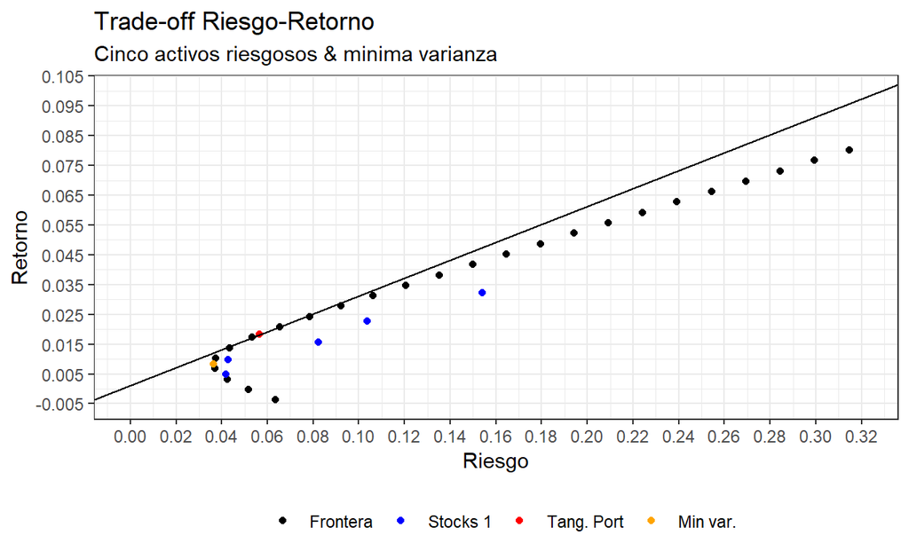

```r
g4 <- ggplot() + geom_point(mapping = aes(eff.front.short$sd, eff.front.short$er, color = "1"))
g4 <- g4 + geom_point(mapping = aes(sd, mean, color = "2"))
g4 <- g4 + geom_point(mapping = aes(port.tang$sd, port.tang$er, color = "3"))
g4 <- g4 + geom_point(mapping = aes(globalmin$sd, globalmin$er, color = "4"))
g4 <- g4 + geom_abline(intercept = rf, slope = sharpe.ratio)
g4 <- g4 + scale_y_continuous(breaks = seq(-0.005,0.2, by = 0.01), limits = c(-0.005,0.1))
g4 <- g4 + scale_x_continuous(breaks = seq(0,0.32, by = 0.02), limits = c(0,0.32))
g4 <- g4 + scale_color_manual("", values = c("black","blue", "red", "orange"),
                              labels = c("Frontera", "Stocks 1", "Tang. Port","Min var."))
g4 <- g4 + theme_bw() + xlab("Riesgo") + ylab("Retorno")
g4 <- g4 + ggtitle("Trade-off Riesgo-Retorno",
                   subtitle = "Cinco activos riesgosos & minima varianza")
g4 <- g4 + theme(legend.position = "bottom")
g4
```

## Pregunta g

```r
# Portafolio tangente sin venta corta
port.tangnoshort <- tangency.portfolio(mean, cov, rf, shorts = FALSE)
port.tangnoshort
```

```
## Call:
## tangency.portfolio(er = mean, cov.mat = cov, risk.free = rf,
##     shorts = FALSE)
##
## Portfolio expected return:     0.01614801
## Portfolio standard deviation:  0.05020754
## Portfolio weights:
## AMZN.Close GOOG.Close NFLX.Close  MCD.Close   KO.Close
##     0.1376     0.1532     0.1653     0.5439     0.0000
```

Repita (3.d) pero ahora la venta corta no está permitida, comente.

[^1]: Para mayor detalle de la función `efficient.frontier` ver desde la slide 31 de la ayudantía 2

**Disclaimer** : La información contenida en esta página está bajo una [Licencia Creative Commons Atribución-NoComercial-SinDerivadas 4.0 Internacional](http://creativecommons.org/licenses/by-nc-nd/4.0/) y fue construida bajo mi rol como ayudante (*Teacher Assistant*) de la Catedra Finanzas I (*Finance I*).